# Lesson 06 - Working with Data

Robin Donatello

Last Updated 07-16-2019

# Introduction

In this lesson we will learn how to summarize data in a data frame, and to do basic data management tasks such as making new variables, recoding data and dealing with missing data.

## Learning Objectives

After completing this lesson learneres will be able to

- Summarize variables inside a data frame
- Make new variables inside a data frame.
- Selectively edit (and recode) data elements.
- Identify when data values are missing
- Summarize data in the presence of missing values.

## Preparation

##### Prior to this lesson learners should

- Download the [06_dm_notes.Rmd] R markdown file and save into your `scripts/Math130` folder.
- Edit the code to import the `NCbirths` data set into this notes file. Run it to make sure it works.
- Install the `dplyr` package.

```r
NCbirths <- read.csv("../data/NCbirths.csv", header=TRUE)
```

# Missing Data

Missing data occurs when the value for a variable is missing. Think of it as a blank cell in an spreadsheet. Missing values can cause some problems during analysis, so let’s see how to detect missing values and how to work around them.

Consider the `NCbirths` data set, specifically the first column containing data on the father’s age (`fage`).

```r
head(NCbirths)
```

```
##   fage mage      mature weeks    premie visits marital gained weight
## 1   NA   13 younger mom    39 full term     10 married     38   7.63
## 2   NA   14 younger mom    42 full term     15 married     20   7.88
## 3   19   15 younger mom    37 full term     11 married     38   6.63
## 4   21   15 younger mom    41 full term      6 married     34   8.00
## 5   NA   15 younger mom    39 full term      9 married     27   6.38
## 6   NA   15 younger mom    38 full term     19 married     22   5.38
##   lowbirthweight gender     habit  whitemom
## 1        not low   male nonsmoker not white
## 2        not low   male nonsmoker not white
## 3        not low female nonsmoker     white
## 4        not low   male nonsmoker     white
## 5        not low female nonsmoker not white
## 6            low   male nonsmoker not white
```

- R puts a `NA` as a placeholder when the value for that piece of data is missing.
- Missing data can be a result of many things: skip patterns in a survey (i.e. non-smokers don’t get asked how many packs per week they smoke), errors in data reads from a machine, etc.

**Problem 1** `R` can’t do arithmetic on missing data. So `5 + NA = NA`, and if you were to try to calculate the `mean()` of a variable, you’d also get `NA`.

```r
mean(NCbirths$fage)
```

```
## [1] NA
```

**Problem 2** Some plots will show `NA` as it’s own category, which is undesirable.

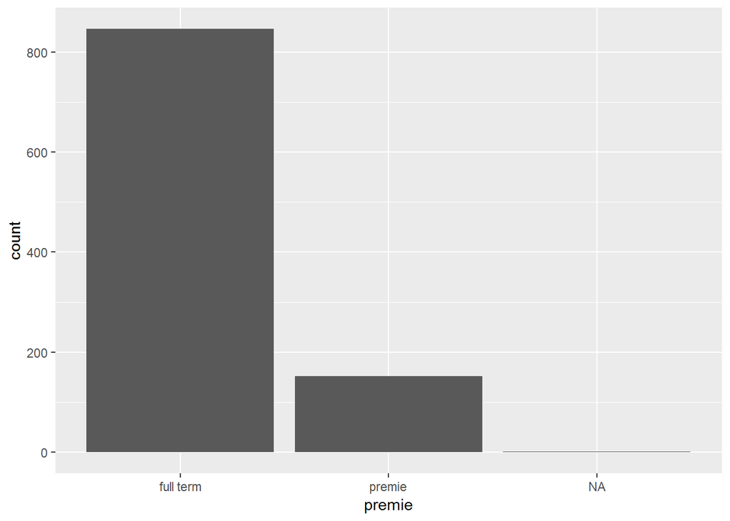

```r
library(ggplot2)
ggplot(NCbirths, aes(premie))+geom_bar()
```

## Identifying missing values

To find out how many values in a particular variable are missing we can use one of two approaches:

1. Look at the raw data using `head()` or `str()`. This may not be helpful if there is no missing values in the first 6 rows, or if there is a large number of variables to look through.
2. Look at data summaries using `table()` for categorical data and `summary()` for numerical data. These functions will be explained in greater detail in the next section, but in the examples below you can see that entries for “NA” are included in the output.

```r
table(NCbirths$habit, useNA="always")
```

```
##
## nonsmoker    smoker      <NA>
##       873       126         1
```

```r
summary(NCbirths$fage)
```

```
##    Min. 1st Qu.  Median    Mean 3rd Qu.    Max.    NA's
##   14.00   25.00   30.00   30.26   35.00   55.00     171
```

### Is it NA?

The `is.na()` function returns TRUE or FALSE for each element in the provided vector for whether or not that element is missing.

```r
is.na(c("green", NA, 3))
```

```
## [1] FALSE  TRUE FALSE
```

This can be used to count the number of missing values in a variable

```r
sum(is.na(NCbirths$fage))
```

```
## [1] 171
```

There are 171 records in this data set where the age for the father is not present.

# Summarizing data

Two common methods used to summarize data are `table()` for categorical factor variables, and `summary()` for numeric variables.

## Frequency Tables for categorical data

Let’s look at the variable for whether or not the baby was born underweight. R acknowledges it is a factor variable already.

```r
class(NCbirths$lowbirthweight)
```

```
## [1] "factor"
```

You can create a frequency table by using the `table()` function. The `useNA="always"` argument tells `R` to always include an entry for missing values `<NA>`, even if there are none.

```r
table(NCbirths$lowbirthweight, useNA="always")
```

```
##
##     low not low    <NA>
##     111     889       0
```

## Summary statistics for numerical data

Numerical variables can be summarized using statistics such as the min, max, mean and median. The function `summary()` prints out the five number summary, and includes the mean. This function also displays the number of missing values for that variable.

```r
summary(NCbirths$visits)
```

```
##    Min. 1st Qu.  Median    Mean 3rd Qu.    Max.    NA's
##     0.0    10.0    12.0    12.1    15.0    30.0       9
```

Mothers included in this data set visited the doctor on average 12.1 times during their pregnancy.

# Recoding data

Sometimes we have a need to edit, or change data. We can change values of existing data by using logical statements.

To choose all observations (rows) of a `data` set, where a `variable` is equal to some `value`, you would type

```r
data[data$variable==value]
```

We can use this method of selecting rows, to change data in those specific rows.

**Example 1: Too low birthweight**

Let’s look at the numerical distribution of birthweight of the baby.

```r
summary(NCbirths$weight)
```

```
##    Min. 1st Qu.  Median    Mean 3rd Qu.    Max.
##   1.000   6.380   7.310   7.101   8.060  11.750
```

The value of 1 lb seems very low. The researchers you are working with decide that is a mistake and should be excluded from the data. We would then set all records where `weight=1` to missing.

```r
NCbirths$weight[NCbirths$weight==1] <- NA
```

The specific variable `NCbirths$weight` is on the far left, outside the `[]`. So just the variable `weight` is being changed.

But what about other weights that aren’t quite as low as 1, but still unusually low? The boxplot below shows outlying values as dots on the low end of birthweight.

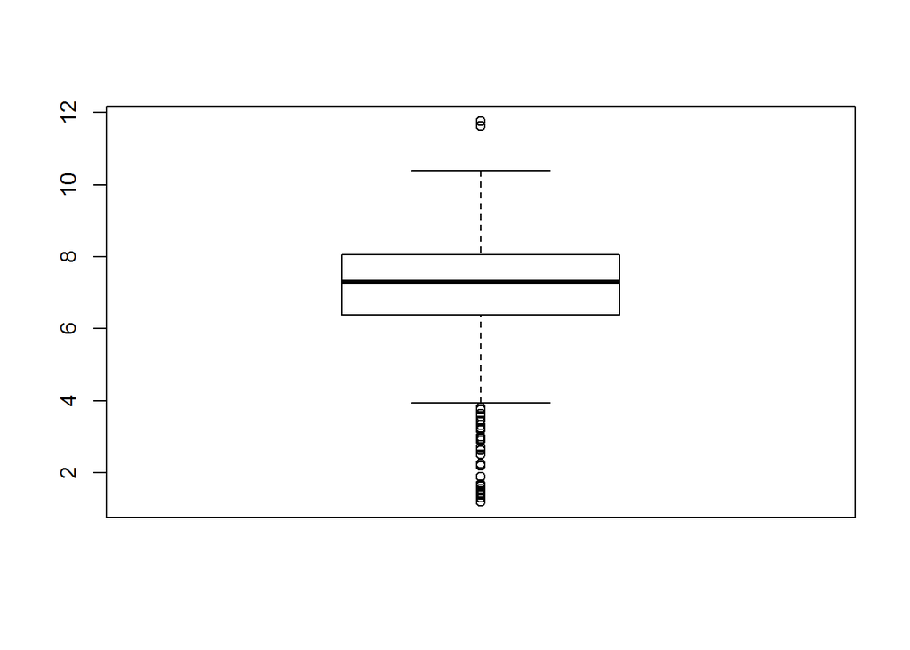

```r
boxplot(NCbirths$weight)
```

Let’s set all birth weights less than 4 lbs to missing.

```r
NCbirths$weight[NCbirths$weight < 4] <- NA
```

It is important to plot the data again, to make sure that there are no values below 4 now.

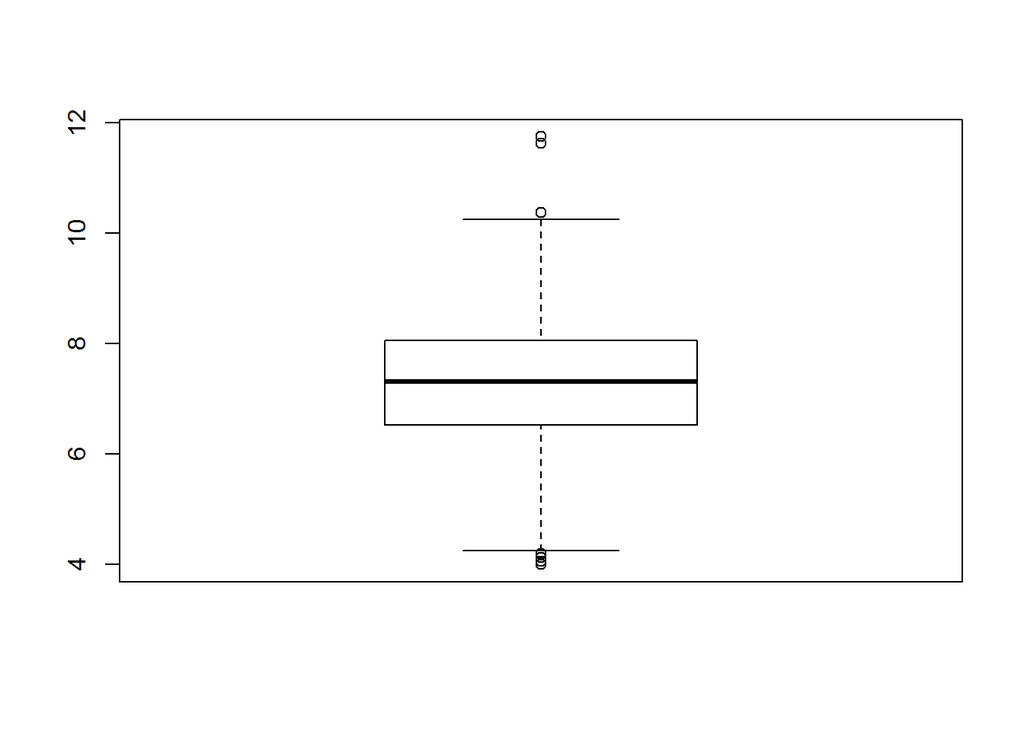

```r
boxplot(NCbirths$weight)
```

# Creating new variables

New variables should be added to the data frame. This can be done using `$` sign notation.

The new variable you want to create goes on the left side of the assignment operator `<-`, and how you want to create that new variable goes on the right side.

```r
data$new_variable <- creation statement
```

#### **Example: Row-wise difference between two existing variables**

As a pregnancy progresses, both the mother and the baby gain weight. The variable `gained` is the total amount of weight the mother gained in her pregnancy. The variable `weight` is how much the baby weighed at birth.

The following code creates a new variable `wtgain_mom` the weight gained by the mother, that is not due to the baby by subtracting `weight` from `gained`.

```r
NCbirths$wtgain_mom <- NCbirths$gained - NCbirths$weight
```

To confirm this variable was created correctly, we look at the data contained in three variables in question.

```r
head(NCbirths[,c('gained', 'weight', 'wtgain_mom')])
```

```
##   gained weight wtgain_mom
## 1     38   7.63      30.37
## 2     20   7.88      12.12
## 3     38   6.63      31.37
## 4     34   8.00      26.00
## 5     27   6.38      20.62
## 6     22   5.38      16.62
```

## Dichtomizing data

The `ifelse()` is hands down the easiest way to create a binary variable (dichotomizing, only 2 levels)

Let’s add a variable to identify if a mother in the North Carolina births data set was underage at the time of birth.

```r
NCbirths$underage <- ifelse(NCbirths$mage <= 18, "underage", "adult")
```

You should always make sure your code works as intended.

- First let’s look at the frequency table of `underage` and see if records exist with the new categories, and if there are any missing values.

```r
table(NCbirths$underage, useNA="always")
```

```
##
##    adult underage     <NA>
##      925       75        0
```

- Next let’s check it against the value of `mage` itself. Let’s look at all rows where mothers age is either 18 or 19 `mage %in% c(18,19)`, and only the columns of interest.

```r
NCbirths[NCbirths$mage %in% c(18,19),c('mage', 'underage')]
```

```
##     mage underage
## 38    18 underage
## 39    18 underage
## 40    18 underage
## 41    18 underage
## 42    18 underage
## 43    18 underage
## 44    18 underage
## 45    18 underage
## 46    18 underage
## 47    18 underage
## 48    18 underage
## 49    18 underage
## 50    18 underage
## 51    18 underage
```

[output cut: 59 more lines]

Notice I snuck a new operator in on you - `%in%`. This is a way you can provide a list of values (a.k.a a vector) and say “if the value of the variable I want is %in% any of these options in this vector…” do the thing.

# Chaining using the pipe %>%

[figure not shown]

The pipe is technically part of the `magrittr` package, but quite often we will use it in conjunction with functions from the `dplyr` package introduced in a later lesson. In fact it’s so commonly used with `dplyr` functions that it the `magrittr` package is loaded when you load `dplyr` (which is what we do here). However, the pipe operator is so useful in many other places that it deserves it’s own introduction here.

> “and then….”

This is what I read to myself when using the pipe (`%>%`). The pipe lets you chain functions together, as long as the first argument of the function is a `data.frame` or a variable in a `data.frame`.

### Example: Frequency tables & summary statistics

Earlier we saw that to create a frequency table for categorical variable we can type:

```r
table(NCbirths$mature)
```

```
##
##  mature mom younger mom
##         133         867
```

This is also accomplished by first stating the variable, then piping in the summary function.

```r
library(dplyr)
NCbirths$mature %>% table()
```

```
## .
##  mature mom younger mom
##         133         867
```

```r
NCbirths$mage %>% mean()
```

```
## [1] 27
```

So in my head i’m reading “Take the `mage` variable on the `NCbirths` data set, *and then* calculate the mean.”

Seems kinda trivial here, the base function without the pipe is pretty easy. But I promise the usefulness will be apparent before the class is out.

# Additional References

This lesson was an introduction to typical basic data management tasks. In a later lesson you will learn how to use functions in the `dplyr` package to perform the same, and more different data management tasks, in a more streamline manner. Both levels of techniques are equally useful depending on the task.

There are always many ways to approach a problem in R. Our goal in this class is to provide you with a few ways to think of a problem. You will find what fits best for your coding style as you progress.

- Tidy Data - The [Journal](http://vita.had.co.nz/papers/tidy-data.pdf), and the [tutorial](https://cran.r-project.org/web/packages/tidyr/vignettes/tidy-data.html)

Resources for handling missing data

- http://www.statmethods.net/input/missingdata.html
- https://stats.idre.ucla.edu/r/faq/how-does-r-handle-missing-values/
- http://faculty.nps.edu/sebuttre/home/R/missings.html